# STA380_exercises

This repository contains responses to the case study exercises for the STA 380 Predictive Models course in the UT McCombs MS Business Analytics program. The case studies can be found [here](https://github.com/jgscott/STA380/blob/master/exercises/README.md).

## Contributors

- Saurabh Bodas
- David Owen
- Pooja Shah
- Hannah Warren

# Visual story telling part 1: green buildings

## Exploratory Analysis

At first glance, it appears that the on-staff stats guru makes valid points about the situaton.

As can be seen below, there is indeed a $2.6 difference in green and non-green buildings. We control for occupancy rates >10%.

```
## # A tibble: 2 x 3
##   green_rating med_rent count
##   <fct>           <dbl> <int>
## 1 0                25.0  6995
## 2 1                27.6   684
```

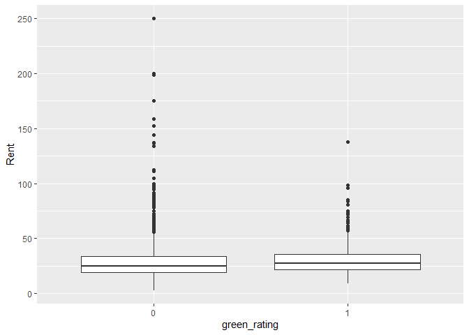

Non-green buildings also have a lot more outliers, and hence the guru’s rationale behind using the median instead of the mean holds true.

### Rent vs. Occupancy Rates

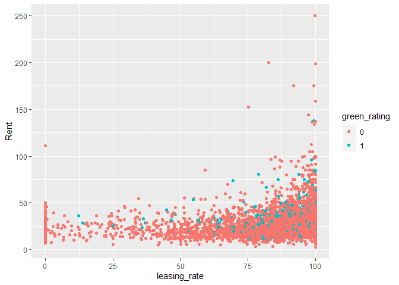

Although the minimum rent holds constant for all values of occupancy rates, it shows a subtle increasing trend with increasing occupancy rates. Let us explore if green buildings have higher occupancy rates.

```
## # A tibble: 2 x 3
##   green_rating med_occupancy count
##   <fct>                <dbl> <int>
## 1 0                     89.2  7209
## 2 1                     92.9   685
```

Green buildings do have slightly higher occupancy rates than non-green buildings. As mentioned in the case study, this could be thanks to better awareness and PR for non-green buildings, but we don’t have enough data to verify this claim.

The guru’s assumption of 90% occupancy rates for the proposed green building is in line with the occupancy rates suggested in our dataset.

### Age vs. Occupancy Rates

Are younger buildings more or less likely to be occupied?

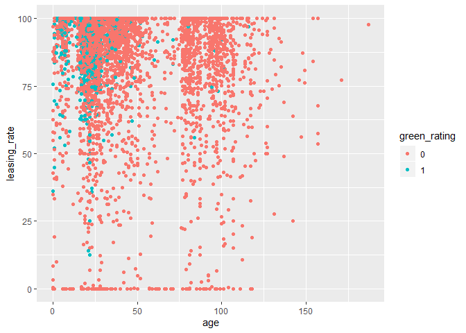

There doesn’t appear to be any defined relationship between the two.

## Confounding Factors

Next, we explore the possibilites of any confounding factors that might indirectly raise the rent for green buildings.

### 1. Amenities

Most green buildings (72%) have amenities (only ~52% in case of non-green), so could this be a factor in raising the rents for green buildings?

```
## # A tibble: 4 x 4
## # Groups:   green_rating [2]
##   green_rating amenities med_rent count
##   <fct>        <fct>        <dbl> <int>
## 1 0            0             25    3550
## 2 0            1             25    3659
## 3 1            0             27     187
## 4 1            1             27.8   498
```

Controlling for amenities, i.e. comparing rents for green & non-green buildings without amenities, there is still a premium for green buildings ($2), and hence this theory does not hold up.

### 2. Number of stories

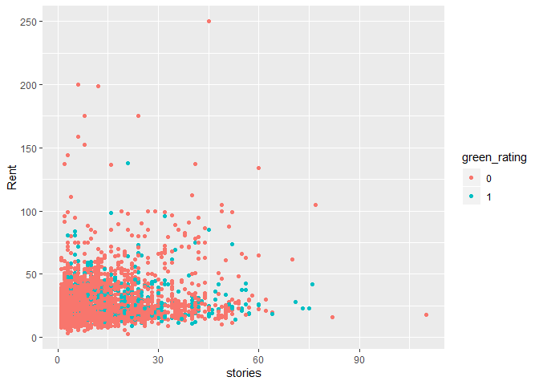

The minimum rent shows an increase with increasing number of stories. Our client may thus be able to demand a higher rent with a taller building.

```
## # A tibble: 2 x 2
##   green_rating med_stories
##   <fct>              <int>
## 1 0                     10
## 2 1                     11
```

Green buildings are in general 1 storey higher than non-green building, but this difference is not strong enough to be considered a confounding factor.

### 3. Size

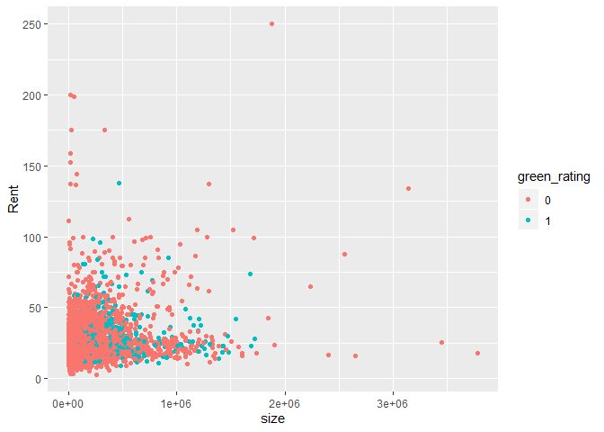

From the graph above, we can see that the rent increases with increasing available leasing space.

```
## # A tibble: 2 x 3
##   green_rating med_size mean_size
##   <fct>           <int>     <dbl>
## 1 0              118696   225977.
## 2 1              241150   325781.
```

Green buildings also appear to have more leasing space in general, and thus, size could be a potential counfounding variable.

### 4. Age

```
## # A tibble: 2 x 3
##   green_rating med_age count
##   <fct>          <int> <int>
## 1 0                 37  7209
## 2 1                 22   685
```

Green buildings are younger by around 15 years. Do newer buildings in general demand higher rent?

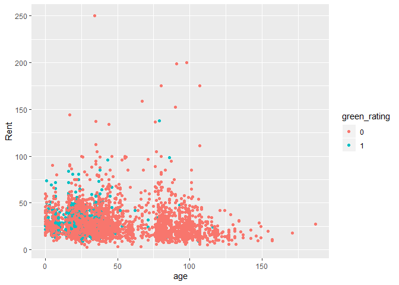

There doesn’t appear to be a particular relationship between age and rent, and hence, age doesn’t appear to be a confounding factor.

```r
summary(buildings$revenue)
```

```
##      Min.   1st Qu.    Median      Mean   3rd Qu.      Max.
##         0    880975   2749485   6536261   7675431 468492211
```

## Further Recommendations

Can revenue for green buildings be maximised by choosing the right locations to build them?

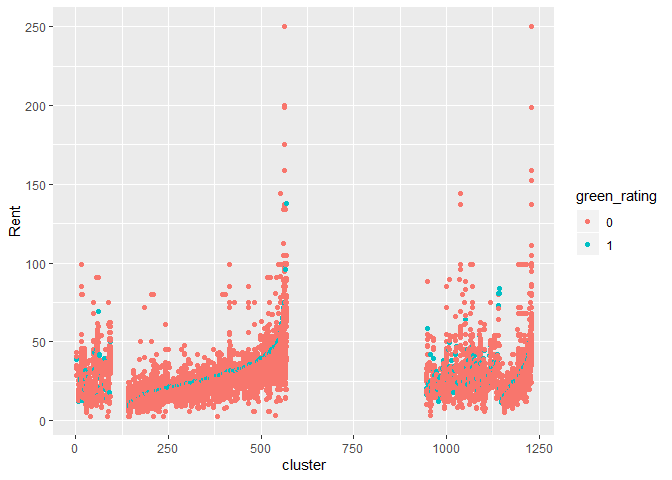

```
## # A tibble: 2 x 3
##   green_rating   med count
##   <fct>        <dbl> <int>
## 1 0             34.2  1492
## 2 1             39.4   131
```

There is a difference of $5 between green and non-green buildings for clusters 430 - 600, possibly due to increased environmental awareness. We could thus generate an additional revenue of $5 * 250,000 = $1.25 million per year.

## Insights

To summarise, we have the following points:

- There is an additional $2.6 in revenue for green buildings vs. traditional buildings, and this difference jumps up to $5 for clusters 430 - 600.
- There is a subtle positive relationship bwtween rent and occupancy rates. Green buildings have a slightly better rate of occupancy, possibly due to their average young age and better PR & advertising opportunities.
- There doesn’t appear to be any correlation between age and occupancy rates.
- On further analysis, we find that rent and size share a subtle positive relationship. Green buildings also, on average, are approximately 100,000 sq. ft. larger than non-green buildings, so this could be a confounding factor. But we need further data to corroborate this claim.

The on-site guru’s hypothesis of being able to recuperate costs in around 8-9 years holds true. The average age for green buildings is currently 22 years, but as green buildings become more popular, we expect them to age and thus, the guru’s assumption that the building would generate revenue for 30 years is fair.

# Visual story telling part 2: flights at ABIA

## Maps

For anyone unfortunate enough to be taking a flight, one of the biggest concerns on their mind might be, “Will my plane be delayed?” Such a possibility is frustratingly common and worse, unpredictable

On the *slightly* brighter side, we can at least tell which flights have historically been delayed more often than most, be it due to weather, traffic, or any other obstruction.

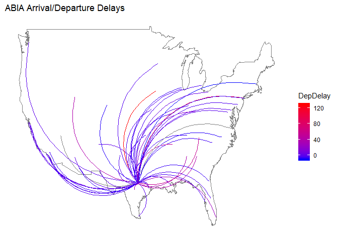

Here is a map of flights to and from Austin-Bergstrom International Airport. Several high-risk flights stand out in red.

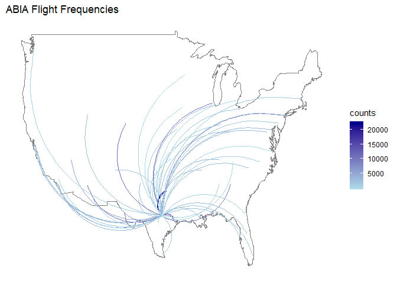

Compare that to how common flights to each destination are, and you can see that the most-delayed flights are not the most common to occur.

## Cancellations

Worse than a flight being delayed is a complete cancellation. See the plots below for the times were flights have historically been cancelled most often, grouped by each airline.

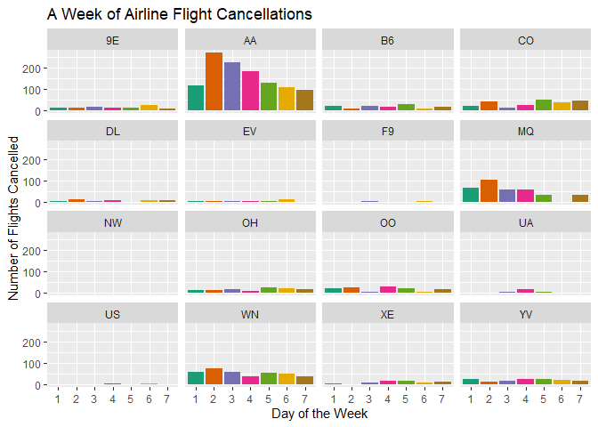

Now let’s examine them by time of day:

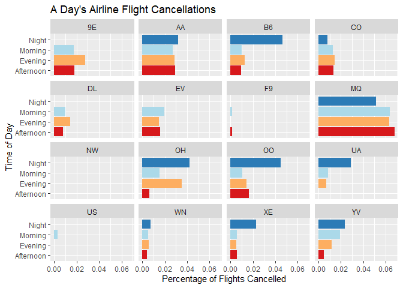

Northwest Airlines had no cancellations!

Below are the types of cancellations that happen during the day.

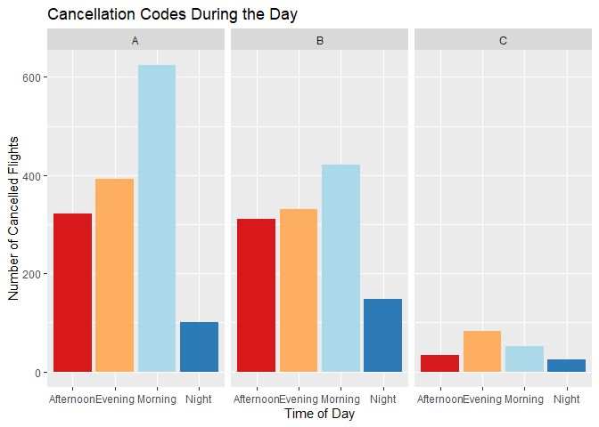

# Portfolio Modeling

Uploading the libraries

[output not shown]

Importing the stocks that we want to use

[output not shown]

Adjusting for splits and dividends

Combining close to close changes in a single matrix

```
## [1] "Portfolio a: "

##               ClCl.EDENa     ClCl.GXCa    ClCl.CXSEa   ClCl.QEMMa
## 2014-06-06 -0.0022484355  0.0002689567 -0.0005862615  0.009933741
## 2014-06-09  0.0015023850  0.0084677014  0.0031286665 -0.002131164
## 2014-06-10  0.0007499906  0.0058643477  0.0077973101  0.000000000
## 2014-06-11 -0.0106801576 -0.0051676030 -0.0069632687  0.000000000
## 2014-06-12  0.0077651517 -0.0006659963 -0.0001947409  0.000000000
## 2014-06-13 -0.0052621501  0.0106624418  0.0126631205  0.018728422
##               ClCl.IEMGa
## 2014-06-06  0.0098951880
## 2014-06-09  0.0032661288
## 2014-06-10  0.0045959019
## 2014-06-11 -0.0032405262
## 2014-06-12 -0.0036336392
## 2014-06-13  0.0001919962

## [1] ""

## [1] "Portfolio b: "

##                ClCl.FSZb   ClCl.JPMVb     ClCl.FCAb    ClCl.TURb
## 2014-06-06 -0.0004515918  0.004694875 -0.0045641716  0.011635866
## 2014-06-09  0.0038400497 -0.007009365  0.0000000000  0.001860639
## 2014-06-10 -0.0045003826 -0.005098000  0.0050436041  0.013000169
## 2014-06-11 -0.0099458178  0.002759145 -0.0018248631 -0.051999983
## 2014-06-12  0.0002283562  0.007665075  0.0009141225  0.004043600
## 2014-06-13 -0.0034238986 -0.001755413  0.0000000000 -0.006303642

## [1] ""

## [1] "Portfolio c: "

##               ClCl.EWJc     ClCl.EWLc     ClCl.EWNc    ClCl.ASHRc
## 2014-01-03  0.005862710  0.0099348032 -0.0015673981 -0.0045454957
## 2014-01-06 -0.003330558 -0.0003073778 -0.0007849686 -0.0249066002
## 2014-01-07  0.004177130  0.0009224785  0.0062844464  0.0021286079
## 2014-01-08  0.001663852 -0.0012289094  0.0003902420  0.0004247239
## 2014-01-09 -0.003322259  0.0055367890  0.0011705424 -0.0148619115
## 2014-01-10  0.006666667  0.0104007345  0.0074045207  0.0073275859
##              ClCl.KFYPc   ClCl.GREKc   ClCl.ERUSc
## 2014-01-03 -0.010716442 -0.010118786 -0.005673712
## 2014-01-06 -0.001547601  0.004888933 -0.019495934
## 2014-01-07  0.002014972  0.026536841  0.004364597
## 2014-01-08  0.014385150  0.026712668 -0.002897127
## 2014-01-09  0.000000000  0.005874906 -0.005326804
## 2014-01-10  0.000000000  0.014184398  0.018500437
```

Computing the returns from the closing prices

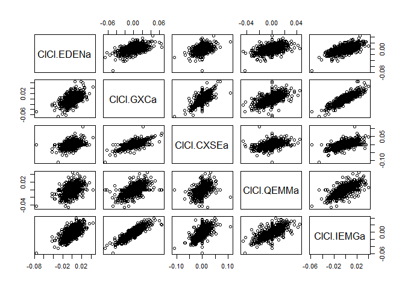

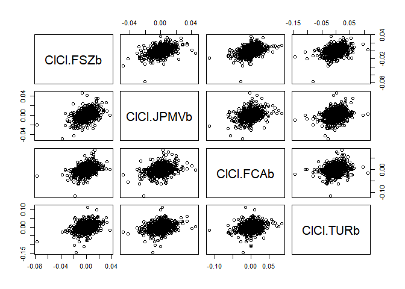

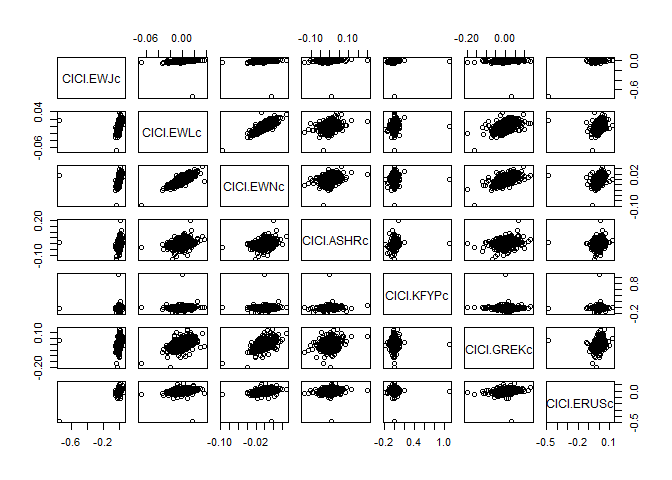

Sampling a random return from the empirical joint distribution

Update the value of my holdings, starting with an equal distribution to each asset

```
## [1] 100952.9

## [1] 98416.81

## [1] 100240.9
```

Loop over 4 trading weeks

```
## [1] 100104.7

## [1] 102691

## [1] 94916.98
```

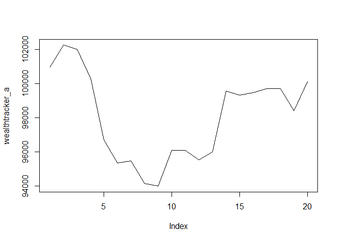

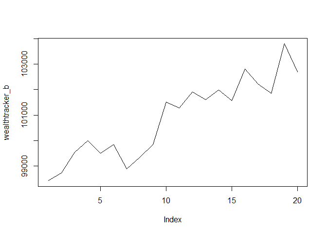

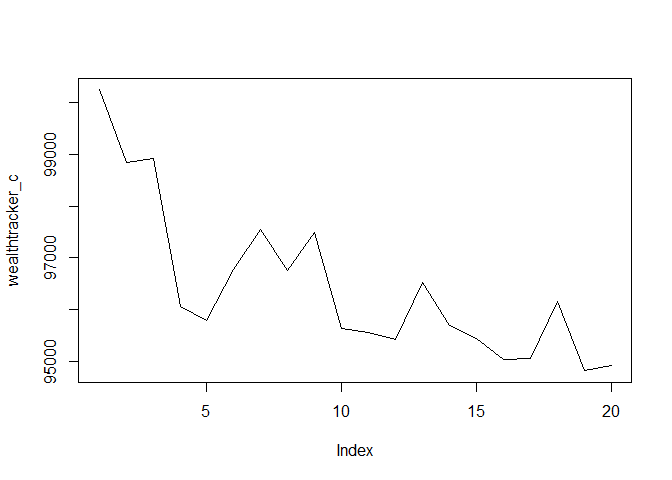

```
##               [,1]      [,2]      [,3]      [,4]      [,5]      [,6]
## result.1  99611.53  99215.10  96809.80  95829.40  94317.40  95026.12
## result.2 100677.99 100197.70 100759.50 100213.31 100721.31 100073.47
## result.3  99555.35 101895.77 101604.30 100125.35 100437.51 100878.09
## result.4 100096.03  99941.09 100049.19  99433.99  99170.13  99957.07
## result.5  98752.10 100013.43  99277.66  99183.40 100457.08  99956.65
## result.6  99086.47  98486.74  98394.70  99334.17  99552.39  98368.74
##               [,7]      [,8]      [,9]     [,10]     [,11]     [,12]
## result.1  95191.21  95389.06  95061.64  95083.53  95234.81  95015.11
## result.2 100783.77 102213.67 102463.05 102584.80 103492.89 103461.98
## result.3 101579.25 101375.36 100967.65 101848.41 101182.62 102946.12
## result.4 101917.95 102457.05 100247.66 101473.53 100236.21 101972.58
## result.5  99375.63  99003.65 100114.64 100020.44 101238.63 100565.79
## result.6  98133.63  98892.87  98359.16  97850.92  97742.41  98408.11
##              [,13]     [,14]     [,15]     [,16]     [,17]     [,18]
## result.1  96168.49  96600.89  95607.15  93961.68  95424.29  95627.37
## result.2 103992.29 106263.77 104676.26 103821.54 104423.08 105469.43
## result.3 104679.86 105244.25 105026.39 107053.76 107224.22 106647.97
## result.4 102244.93 102151.25 102736.69 104108.61 103968.79 103530.06
## result.5 100883.92 101571.38 100841.96 100863.64 102028.27 102665.45
## result.6  99721.42  99748.20  99860.20 101479.76 101469.15 101007.98
##              [,19]    [,20]
## result.1  94948.52  93645.5
## result.2 105560.39 106219.1
## result.3 107018.03 105052.5
## result.4 101108.95 100888.2
## result.5 101728.17 101362.0
## result.6 101339.96  99795.8
```

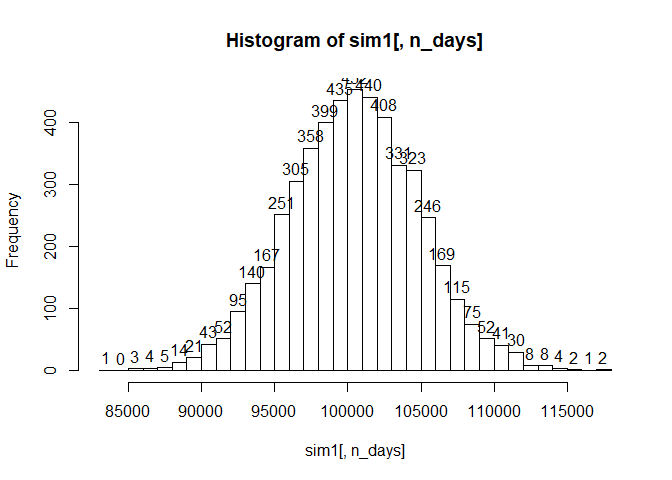

```
##       5%
## 93111.26
```

Second Portfolio

```
##               [,1]      [,2]      [,3]      [,4]      [,5]      [,6]
## result.1 100069.09  99504.49 100239.77 101742.54 102306.67 102292.39
## result.2 100212.53 100428.40 102200.01 104151.79 103875.69 103657.38
## result.3 100853.32 101869.97 102674.87 102639.20 103702.01 105245.96
## result.4 100871.72 101898.85 101842.91 102619.58 102834.31 102624.07
## result.5  99857.27  97376.31  98003.09  97887.97  97793.52  97413.71
## result.6 100527.75  99963.53  99971.77 101271.77 101545.28 101542.11
##               [,7]      [,8]      [,9]     [,10]     [,11]     [,12]
## result.1 102000.15 100125.32  99595.93 100079.51  99793.38  99690.28
## result.2 102396.45 102949.80 103368.60 103144.50 103589.20 103389.24
## result.3 105299.76 105808.16 106400.91 106658.02 107398.08 107251.09
## result.4 103254.17 102544.38 103836.22 104190.83 104714.52 103194.47
## result.5  97309.82  96628.53  97257.68  97443.53  96391.40  96322.86
## result.6 101347.86  99398.50  99657.77  99041.67  99408.89  99741.64
##              [,13]     [,14]     [,15]     [,16]    [,17]    [,18]
## result.1  99520.97 100455.89 100249.48 100049.60 101991.5 103088.5
## result.2 103184.53 104923.90 104668.27 104829.71 104458.0 104404.1
## result.3 106588.64 106738.72 107097.80 107051.86 107031.5 107344.6
## result.4 103500.55 103138.94 104110.34 104732.24 105984.9 106578.2
## result.5  96334.62  99057.13  99248.74  98873.59 100508.0 100180.5
## result.6 100194.32 100245.25 100638.97 102129.36 102503.9 102835.9
##             [,19]    [,20]
## result.1 103282.5 103049.8
## result.2 105836.4 105456.5
## result.3 105377.3 104223.6
## result.4 105441.5 107499.8
## result.5 102197.1 100493.1
## result.6 102194.3 101777.8
```

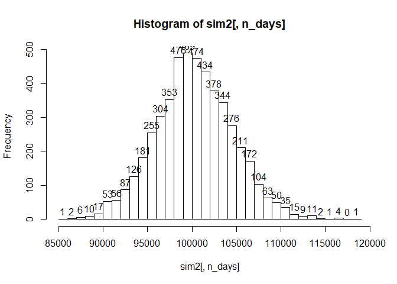

```
##       5%
## 93234.85
```

Portfolio C

```
##               [,1]      [,2]      [,3]      [,4]      [,5]      [,6]
## result.1  99842.84 100729.01 101138.92 100325.41 101124.20 102330.98
## result.2 101007.11 102304.86 104051.95 103549.75 102710.24 104394.14
## result.3 100201.08 100019.15 100282.81 100239.82  99771.65 100446.96
## result.4  99873.81 100154.12 100784.25 100679.43 101759.51 102122.56
## result.5  99026.10  98309.49  98402.94  98606.19  98723.05  98719.79
## result.6  99636.22  99993.29 100806.06 101094.28 100260.40 101122.38
##               [,7]      [,8]      [,9]     [,10]     [,11]     [,12]
## result.1 102570.79 102591.26 103943.39  99933.63 100376.19 102625.27
## result.2 105053.62 103970.13 104533.71 104930.00 105824.21 105838.19
## result.3 101159.16 102791.33 102825.78 103342.50 104319.07 103965.51
## result.4 101531.89  99416.44 100128.82  99554.44  99296.60  98838.27
## result.5  98190.96  95893.17  96722.86  98347.42  97685.76  96694.08
## result.6 100309.67  99290.68  98837.29  99065.03  99438.31  99733.73
##              [,13]     [,14]     [,15]     [,16]     [,17]     [,18]
## result.1  99717.27  98401.74  97314.15  96578.42  96056.96  95911.96
## result.2 105522.67 105864.06 105485.29 104840.33 105994.52 106543.87
## result.3 104245.80 106125.72 105430.60 104846.94 106302.47 107860.42
## result.4  97472.03  98428.83  97706.93  96901.01  95735.28  94260.28
## result.5  97078.66  96098.15  95387.28  95535.45  95745.94  95841.02
## result.6 100486.77 103565.86 103685.16 104106.71 105451.08 105620.23
##              [,19]     [,20]
## result.1  95723.14  93308.63
## result.2 109226.27 106359.30
## result.3 106852.67 105159.78
## result.4  91934.46  89580.77
## result.5  95689.65  96766.28
## result.6 105146.26 104784.34
```

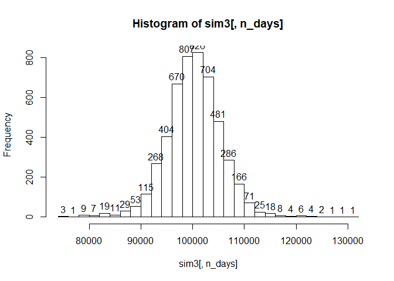

```
##       5%
## 92038.78
```

# Market Segmentation

## Data Description

We have a dataset of the number of tweets from customers of an anonymised firm, in terms of categories of the tweets.

A brief summary of the data:

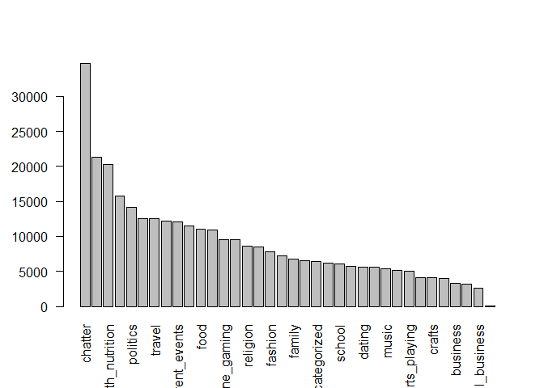

âChatter’ category (uncategorised posts) has the most number of posts, which isn’t informative. Photo-sharing, nutrition, cooking, and politics are also popular categories.

Are there any categories that are positively correlated with each other?

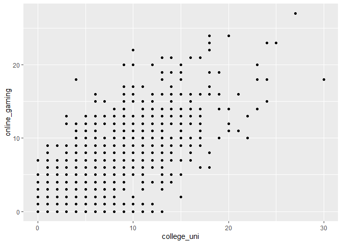

Online gaming and universties are correlated categories. Let us plot a correlation for all categories.

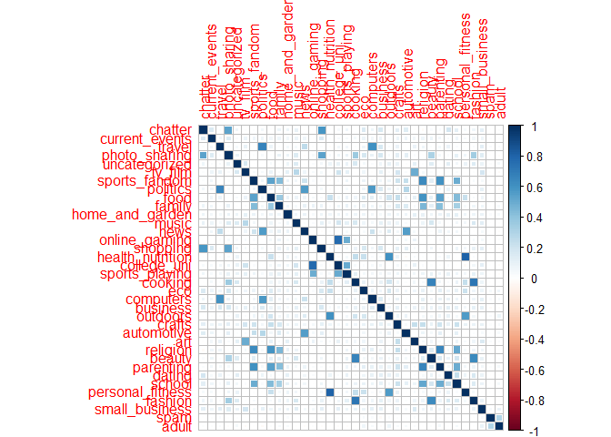

The following categories are highly correlated: (represented by dark squares)

1. Personal fitness & nutrition,
2. fashion and cooking,
3. politics and travel,
4. religion and sports fandom
5. Online gaming and universities

However, these show us correlations in two dimensions. To better understand market segments, let us perform k-means clustering.

## K-means Clustering

Including only the measureable categories for clustering:

### Choosing the value of K

Choosing the number of clusters is completely subjective based either on business goals or mathematical basis. Let us plot the elbow plot to get a sense of the number of clusters to be used.

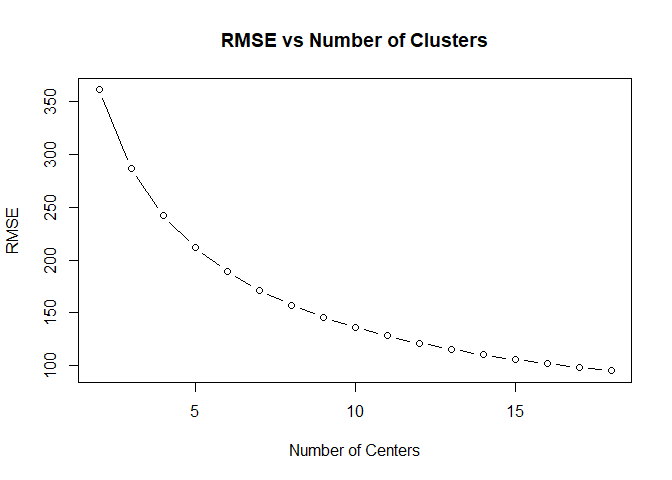

Let us choose k = 5 as the optimum number of clusters.

K-means clustering will provide us with information on what posts are tweeted togeher, which will help us create buyer personas in order to better tailor advertising campaigns.